# Introduction

This data came from an online website called data.world. It was initially collected in 2014 and then revised in 2015. It includes 8,789 food items and lists the amounts they contain of different nutrients. The source is the United States Department of Agriculture.

Here is the link to my data: https://data.world/awram/food-nutritional-values

```python
import pandas as pd
df = pd.read_excel('https://query.data.world/s/h5xr3mwavgls7t2g65zgtpgy2yvz4y?dws=00000')

df
```

|  | NDB_No | Shrt_Desc | Water_(g) | Energ_Kcal | Protein_(g) | Lipid_Tot_(g) | Ash_(g) | Carbohydrt_(g) | Fiber_TD_(g) | Sugar_Tot_(g) | ... | Vit_K_(µg) | FA_Sat_(g) | FA_Mono_(g) | FA_Poly_(g) | Cholestrl_(mg) | GmWt_1 | GmWt_Desc1 | GmWt_2 | GmWt_Desc2 | Refuse_Pct |
| --- | --- | --- | --- | --- | --- | --- | --- | --- | --- | --- | --- | --- | --- | --- | --- | --- | --- | --- | --- | --- | --- |
| 0 | 1001 | BUTTER,WITH SALT | 15.87 | 717 | 0.85 | 81.11 | 2.11 | 0.06 | 0.0 | 0.06 | ... | 7.0 | 51.368 | 21.021 | 3.043 | 215.0 | 5.00 | 1 pat, (1" sq, 1/3" high) | 14.2 | 1 tbsp | 0.0 |
| 1 | 1002 | BUTTER,WHIPPED,W/ SALT | 16.72 | 718 | 0.49 | 78.30 | 1.62 | 2.87 | 0.0 | 0.06 | ... | 4.6 | 45.390 | 19.874 | 3.331 | 225.0 | 3.80 | 1 pat, (1" sq, 1/3" high) | 9.4 | 1 tbsp | 0.0 |
| 2 | 1003 | BUTTER OIL,ANHYDROUS | 0.24 | 876 | 0.28 | 99.48 | 0.00 | 0.00 | 0.0 | 0.00 | ... | 8.6 | 61.924 | 28.732 | 3.694 | 256.0 | 12.80 | 1 tbsp | 205.0 | 1 cup | 0.0 |
| 3 | 1004 | CHEESE,BLUE | 42.41 | 353 | 21.40 | 28.74 | 5.11 | 2.34 | 0.0 | 0.50 | ... | 2.4 | 18.669 | 7.778 | 0.800 | 75.0 | 28.35 | 1 oz | 17.0 | 1 cubic inch | 0.0 |
| 4 | 1005 | CHEESE,BRICK | 41.11 | 371 | 23.24 | 29.68 | 3.18 | 2.79 | 0.0 | 0.51 | ... | 2.5 | 18.764 | 8.598 | 0.784 | 94.0 | 132.00 | 1 cup, diced | 113.0 | 1 cup, shredded | 0.0 |
| ... | ... | ... | ... | ... | ... | ... | ... | ... | ... | ... | ... | ... | ... | ... | ... | ... | ... | ... | ... | ... | ... |
| 8785 | 83110 | MACKEREL,SALTED | 43.00 | 305 | 18.50 | 25.10 | 13.40 | 0.00 | 0.0 | 0.00 | ... | 7.8 | 7.148 | 8.320 | 6.210 | 95.0 | 80.00 | 1 piece, (5-1/2" x 1-1/2" x 1/2") | 17.0 | 1 cubic inch, boneless | 0.0 |
| 8786 | 90240 | SCALLOP,(BAY&SEA),CKD,STMD | 70.25 | 111 | 20.54 | 0.84 | 2.97 | 5.41 | 0.0 | 0.00 | ... | 0.0 | 0.218 | 0.082 | 0.222 | 41.0 | 85.00 | 3 oz | NaN | NaN | 0.0 |
| 8787 | 90480 | SYRUP,CANE | 26.00 | 269 | 0.00 | 0.00 | 0.86 | 73.14 | 0.0 | 73.20 | ... | 0.0 | 0.000 | 0.000 | 0.000 | 0.0 | 21.00 | 1 serving | NaN | NaN | 0.0 |
| 8788 | 90560 | SNAIL,RAW | 79.20 | 90 | 16.10 | 1.40 | 1.30 | 2.00 | 0.0 | 0.00 | ... | 0.1 | 0.361 | 0.259 | 0.252 | 50.0 | 85.00 | 3 oz | NaN | NaN | 0.0 |
| 8789 | 93600 | TURTLE,GREEN,RAW | 78.50 | 89 | 19.80 | 0.50 | 1.20 | 0.00 | 0.0 | 0.00 | ... | 0.1 | 0.127 | 0.088 | 0.170 | 50.0 | 85.00 | 3 oz | NaN | NaN | 0.0 |

8790 rows × 53 columns

# Preprocessing

```python
# Imports

import numpy as np
import pandas as pd
import seaborn as sns
from sklearn.preprocessing import StandardScaler
import matplotlib.pyplot as plt
```

```python
columns = ["NDB_No", "Shrt_Desc", "Water_(g)", "Energ_Kcal", "Protein_(g)", "Lipid_Tot_(g)", "Carbohydrt_(g)", "Fiber_TD_(g)"]
df = df[columns]
df.shape
```

```
(8790, 8)
```

```python
df.dropna(inplace=True)
df.shape
```

```
(8195, 8)
```

The next cell adds a categorical column to the data frame. This colomn is true if the item contains protein, and false if not.

```python
df["has_Protein"] = df["Protein_(g)"] > 0
df
```

|  | NDB_No | Shrt_Desc | Water_(g) | Energ_Kcal | Protein_(g) | Lipid_Tot_(g) | Carbohydrt_(g) | Fiber_TD_(g) | has_Protein |
| --- | --- | --- | --- | --- | --- | --- | --- | --- | --- |
| 0 | 1001 | BUTTER,WITH SALT | 15.87 | 717 | 0.85 | 81.11 | 0.06 | 0.0 | True |
| 1 | 1002 | BUTTER,WHIPPED,W/ SALT | 16.72 | 718 | 0.49 | 78.30 | 2.87 | 0.0 | True |
| 2 | 1003 | BUTTER OIL,ANHYDROUS | 0.24 | 876 | 0.28 | 99.48 | 0.00 | 0.0 | True |
| 3 | 1004 | CHEESE,BLUE | 42.41 | 353 | 21.40 | 28.74 | 2.34 | 0.0 | True |
| 4 | 1005 | CHEESE,BRICK | 41.11 | 371 | 23.24 | 29.68 | 2.79 | 0.0 | True |
| ... | ... | ... | ... | ... | ... | ... | ... | ... | ... |
| 8785 | 83110 | MACKEREL,SALTED | 43.00 | 305 | 18.50 | 25.10 | 0.00 | 0.0 | True |
| 8786 | 90240 | SCALLOP,(BAY&SEA),CKD,STMD | 70.25 | 111 | 20.54 | 0.84 | 5.41 | 0.0 | True |
| 8787 | 90480 | SYRUP,CANE | 26.00 | 269 | 0.00 | 0.00 | 73.14 | 0.0 | False |
| 8788 | 90560 | SNAIL,RAW | 79.20 | 90 | 16.10 | 1.40 | 2.00 | 0.0 | True |
| 8789 | 93600 | TURTLE,GREEN,RAW | 78.50 | 89 | 19.80 | 0.50 | 0.00 | 0.0 | True |

8195 rows × 9 columns

The next cells define a function to determine if a given value is an outlier using the 1.5 * IQR standard. This means that if a value is more than 1.5 * the IQR less than Q1 or greater than Q3, it is considered an outlier. Then this is applied to the columns of interest in order to determine how many outliers there are.

```python
def is_outlier(x):
    Q25, Q75 = x.quantile([.25,.75])
    I = Q75 - Q25
    return (x < Q25 - 1.5*I) |  (x > Q75 + 1.5*I)

outliers_water = is_outlier(df["Water_(g)"])
outliers_water.sum()
```

```
0
```

```python
outliers_energy = is_outlier(df["Energ_Kcal"])
outliers_energy.sum()
```

```
136
```

```python
outliers_protein = is_outlier(df["Protein_(g)"])
outliers_protein.sum()
```

```
41
```

```python
outliers_lipid = is_outlier(df["Lipid_Tot_(g)"])
outliers_lipid.sum()
```

```
454
```

```python
outliers_carb = is_outlier(df["Carbohydrt_(g)"])
outliers_carb.sum()
```

```
25
```

```python
outliers_fiber = is_outlier(df["Fiber_TD_(g)"])
outliers_fiber.sum()
```

```
734
```

After running the outlier function on all the quantitative columns of interest, we find the following amounts of outliers:

- Water: 0
- Energy: 136
- Protein: 41
- Total Lipids: 454
- Carbohydrates: 25
- Fiber (dietary): 734

It is interesting that the water category doesn't have any. This tells us that none of the food items have a water content drastically above or below all the rest.

We should also recognize that the presence of such a large number of outliers in the fiber category means that there is a lot of variability in the fiber content of the foods in our data set. The total lipids category also has a large number but is not as extreme of a case as fiber.

# Summary Data Analysis

The following cells show summary statistics (count, mean, standard deviation, each quartile, and the max) and relevant graphs (Empirical CDF, PDF) for each of the columns of interest. The units for the energy column are Kcals, and for all other columns they are grams.

```python
# Water
df["Water_(g)"].describe()
```

```
count    8195.000000
mean       53.626142
std        30.808801
min         0.000000
25%        28.255000
50%        62.670000
75%        77.200000
max       100.000000
Name: Water_(g), dtype: float64
```

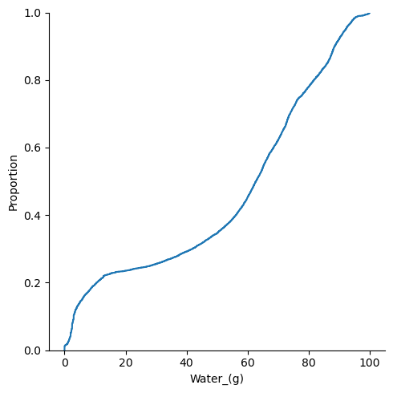

```python
sns.displot(df["Water_(g)"], kind="ecdf");
```

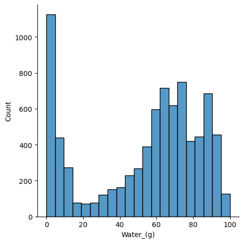

```python
sns.displot(df["Water_(g)"], kind="hist");
```

```python
# Energy
df["Energ_Kcal"].describe()
```

```
count    8195.000000
mean      228.613179
std       169.683531
min         0.000000
25%        95.000000
50%       193.000000
75%       341.000000
max       902.000000
Name: Energ_Kcal, dtype: float64
```

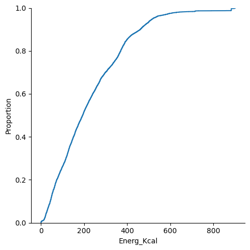

```python
sns.displot(df["Energ_Kcal"], kind="ecdf");
```

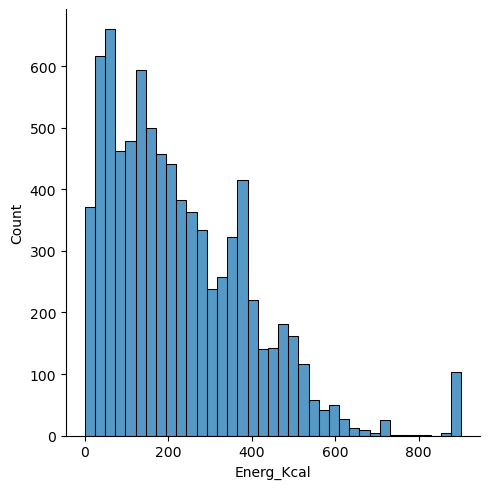

```python
sns.displot(df["Energ_Kcal"], kind="hist");
```

From these graphs we see that there are more foods in the data set that are between 0 and 400 calories than 400 and 800 meaning it is more common for foods to be lower in calories.

```python
# Protein
df["Protein_(g)"].describe()
```

```
count    8195.000000
mean       11.419850
std        10.516845
min         0.000000
25%         2.400000
50%         8.180000
75%        20.050000
max        88.320000
Name: Protein_(g), dtype: float64
```

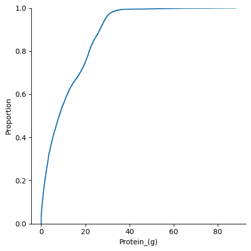

```python
sns.displot(df["Protein_(g)"], kind="ecdf");
```

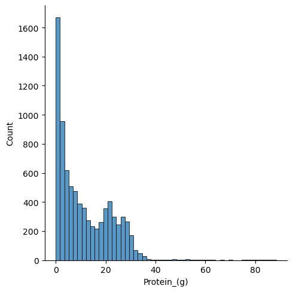

```python
sns.displot(df["Protein_(g)"], kind="hist");
```

These graphs show that more foods have low amounts of protein than have very high aounts. There is a large amount of foods that have no protein at all.

```python
# Total Lipid
df["Lipid_Tot_(g)"].describe()
```

```
count    8195.000000
mean       10.660617
std        15.803175
min         0.000000
25%         1.050000
50%         5.330000
75%        13.875000
max       100.000000
Name: Lipid_Tot_(g), dtype: float64
```

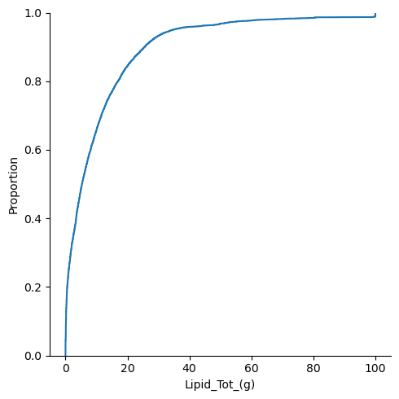

```python
sns.displot(df["Lipid_Tot_(g)"], kind="ecdf");
```

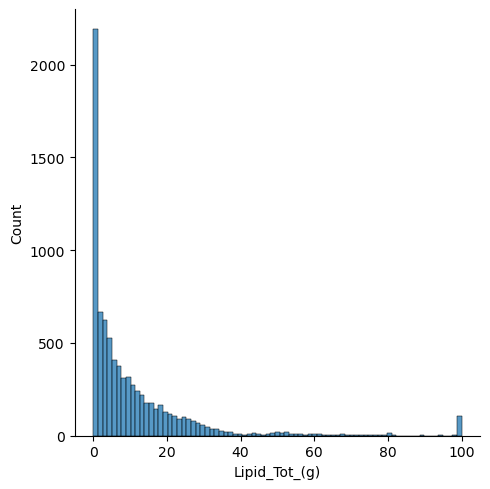

```python
sns.displot(df["Lipid_Tot_(g)"], kind="hist");
```

These graphs show that there are a lot of foods that have no lipids and very few that have a very high total lipid content.

```python
# Carbohydrates
df["Carbohydrt_(g)"].describe()
```

```
count    8195.000000
mean       22.435128
std        27.494874
min         0.000000
25%         0.030000
50%         9.570000
75%        37.640000
max       100.000000
Name: Carbohydrt_(g), dtype: float64
```

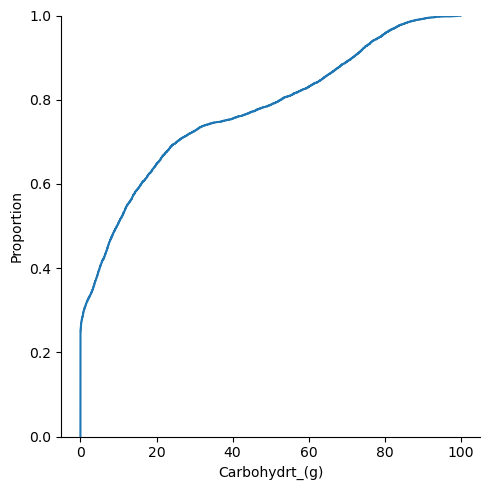

```python
sns.displot(df["Carbohydrt_(g)"], kind="ecdf");
```

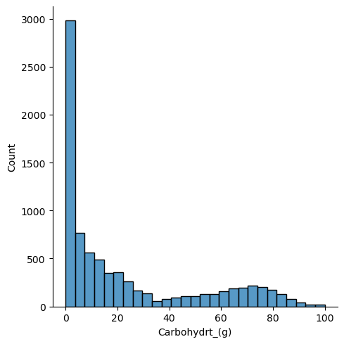

```python
sns.displot(df["Carbohydrt_(g)"], kind="hist");
```

These graphs show that many foods in the data set have 0 carbohydrates and that foods that do have carbohydrages are pretty evenly spread out in their amounts.

```python
# Fiber
df["Fiber_TD_(g)"].describe()
```

```
count    8195.000000
mean        2.187126
std         4.383311
min         0.000000
25%         0.000000
50%         0.700000
75%         2.600000
max        79.000000
Name: Fiber_TD_(g), dtype: float64
```

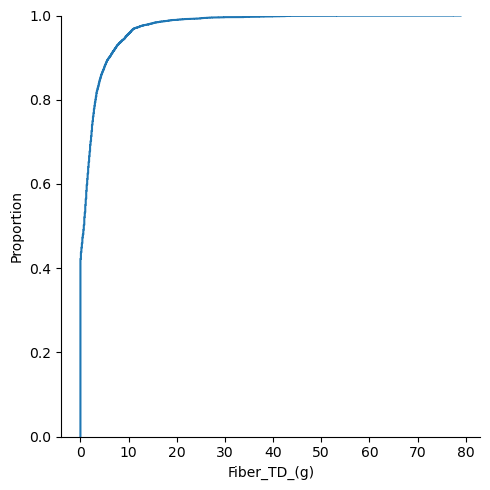

```python
sns.displot(df["Fiber_TD_(g)"], kind="ecdf");
```

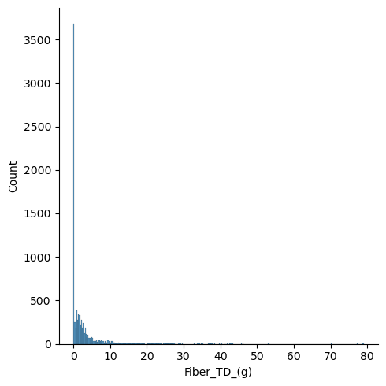

```python
sns.displot(df["Fiber_TD_(g)"], kind="hist");
```

These graphs show that there is a very high number of foods in the data set that have 0g of fiber. Most foods that do have fiber have between 1 and 10 grams and there are also some foods that have a very high fiber content.

# Correlations

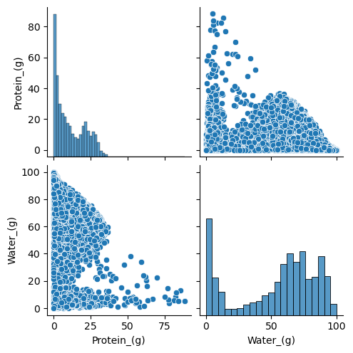

```python
columns1 = ["Protein_(g)", "Water_(g)"]
sns.pairplot(data=df[columns1])
```

```python
df[columns1].corr()
```

|  | Protein_(g) | Water_(g) |
| --- | --- | --- |
| Protein_(g) | 1.000000 | -0.089458 |
| Water_(g) | -0.089458 | 1.000000 |

```python
df[columns1].corr("spearman")
```

|  | Protein_(g) | Water_(g) |
| --- | --- | --- |
| Protein_(g) | 1.000000 | -0.285706 |
| Water_(g) | -0.285706 | 1.000000 |

The Pearson correlation coefficient between protein and water being close to zero, suggests they do not have a strong correlation. I looked at the Spearman coefficient to ensure that outliers were not too strongly affecting the results, and it was further from zero but a weak association. It is negative which suggests that a lower water content would indicate a higher protein content.

2. Analyzing the correlation between energy and carbohydrates.

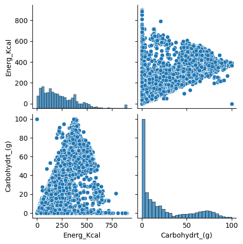

```python
columns2 = ["Energ_Kcal", "Carbohydrt_(g)"]
sns.pairplot(data=df[columns2])
```

```python
df[columns2].corr()
```

|  | Energ_Kcal | Carbohydrt_(g) |
| --- | --- | --- |
| Energ_Kcal | 1.000000 | 0.494455 |
| Carbohydrt_(g) | 0.494455 | 1.000000 |

```python
df[columns2].corr("spearman")
```

|  | Energ_Kcal | Carbohydrt_(g) |
| --- | --- | --- |
| Energ_Kcal | 1.000000 | 0.373511 |
| Carbohydrt_(g) | 0.373511 | 1.000000 |

The Pearson correlation coefficient between energy and carbohydrates suggests a moderate positive association. This means that a higher carbohydrate content is correlated to higher energy content. I looked at the Spearman coefficient to ensure that outliers were not too strongly affecting the results, and it was weaker than the Pearson but still moderately positive.

3. Analyzing the correlation between protein and fiber content.

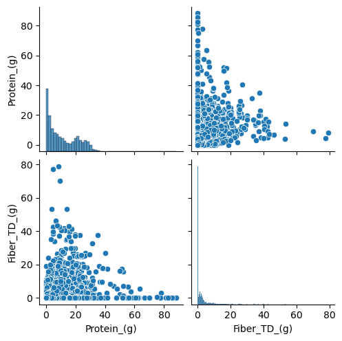

```python
columns3 = ["Protein_(g)", "Fiber_TD_(g)"]
sns.pairplot(data=df[columns3])
```

```python
df[columns3].corr()
```

|  | Protein_(g) | Fiber_TD_(g) |
| --- | --- | --- |
| Protein_(g) | 1.000000 | -0.081103 |
| Fiber_TD_(g) | -0.081103 | 1.000000 |

```python
df[columns3].corr("spearman")
```

|  | Protein_(g) | Fiber_TD_(g) |
| --- | --- | --- |
| Protein_(g) | 1.00000 | -0.31047 |
| Fiber_TD_(g) | -0.31047 | 1.00000 |

The Pearson correlation coefficient between protein and fiber suggests no association. The result is close to zero which would be absolutely no association. I looked at the Spearman coefficient to ensure that outliers were not too strongly affecting the results, and it was weakly negative which would mean higher protein content is associated with lower fiber content.

# Discussion

My Questions:

1. Does a food item having a high amount of water, fiber, and energy increase the chances it has protein? (categorical)
2. Can the amount of protien, carbohydrates, and fiber a food item has be used to predict if it is above average (of those in this data set) in its amount of energy?